# Chapter 13 Homework

AP

2/13/2022

[output not shown]

[output not shown]

[output not shown]

[output not shown]

[output not shown]

[output not shown]

[output not shown]

[output not shown]

[output not shown]

[output not shown]

[output not shown]

[output not shown]

## Question 1

Error is 1; residual is .9.

## Question 2

Y = $\beta_0$ + $\beta_1$A + $\beta_2$B

## Question 3

For every unit increase in X, Y increases by 3 units.

95% CI for $\beta_1$: 3 $\pm$ 2(1.3) = (.4, 5.6); $\beta_1$ is statistically significantly different from 0.

It is extremely unlikely that X and Y are not related.

## Question 4

One additional year of education is associated with a 76.2-hour increase in annual work when adjusting for number of children under 5.

Standard error on the children under 5 coefficient is 19.7 hours when not adjusting for education.

A woman with no children under 5 and no years of education is expected to work 306.6 hours annually.

3,382 observations are used in each model.

Yes, in both models in which it’s included (2 and 3) it’s significant at the 99% level (and so also at the 95% level).

## Question 5

One year increase in YearsEducation produces a 110.23 - 3.162(YearsEducation) change in HoursWorked.

The relationship is getting less positive as YearsEducation increases.

We don’t want to overfit our model to the data.

## Question 6

Homeowners work, on average, 50.2 hours more annually than non-homeowners.

People with 4 children under 5 work, on average, 150.5 hours less annually than people with 3 children under 5.

No; we would need to perform another regression with either 2 or 3 kids under 5 as the reference category.

## Question 7

A one-year increase in education corresponds to a 110.073-hour increase in annual work.

Annual earnings rise faster for homeowning families; this is significant at the .01 level.

The effect of education on annual hours worked gets weaker by 54 hours/year when the family is homeowning.

A one-year increase in education corresponds to a 16.7% increase in annual hours worked.

A 10% increase in education corresponds to a 83.2-hour increase in annual work.

Can’t take the log of 0, so they may have left the 0s on the dependent variable out of model 2 and the 0s on education out of model 3.

## Question 8

B

## Question 9

B, D

## Question 10

Sample weights. Calculate the probability of a person from each demographic being selected for the sample, then use the inverse of that probability as the sample weight.

## Question 11

A

## Coding Questions 1 & 2

```r
dengue <- read_csv("dengue.csv")
```

```
## * `` -> ...1
```

```r
m2 <- stan_glm(NoYes ~ humid,
                      data = dengue,
                      family = gaussian,
                      chains = 4, iter = 4000*2, seed = 1818)
tidy(m2)
```

```
## # A tibble: 2 × 3
##   term        estimate std.error
##   <chr>          <dbl>     <dbl>
## 1 (Intercept)  -0.416    0.0188
## 2 humid         0.0498   0.00102
```

## Coding Question 3

At 0 humidity, there is (in theory) a less-than-0 chance of dengue fever being detected.

For every unit increase of humidity, the probability of detecting dengue fever increases by .05.

## Coding Question 4

```r
dengue |>
  select(humid) |>
  drop_na() |>
  summarize(
    mean = mean(humid),
    min = min(humid),
    max = max(humid),
    median = median(humid)
  )
```

```
## # A tibble: 1 × 4
##    mean   min   max median
##   <dbl> <dbl> <dbl>  <dbl>
## 1  16.7 0.671  30.3   16.1
```

It’s essentially impossible in this dataset to have a humidity of 0, so it makes sense that the value for humidity = 0 doesn’t make sense in reality.

## Coding Question 5

```r
m5 <- stan_glm(NoYes ~ humid + temp,
                      data = dengue,
                      family = gaussian,
                      chains = 4, iter = 4000*2, seed = 1818)
tidy(m5)
```

```
## # A tibble: 3 × 3
##   term        estimate std.error
##   <chr>          <dbl>     <dbl>
## 1 (Intercept) -0.407     0.0190
## 2 humid        0.0528    0.00197
## 3 temp        -0.00326   0.00179
```

## Coding Question 6

```r
m6 <- stan_glm(NoYes ~ humid + temp,
                      data = dengue,
                      family = binomial,
                      chains = 4, iter = 4000*2, seed = 1818)

m6margins <- m6 |>
  margins(variables = c('humid','temp')) |>
  summary()

m6margins
```

```
##  factor    AME     SE   z      p  lower  upper
##   humid 0.0317 0.0000 Inf 0.0000 0.0317 0.0317
##    temp 0.0042 0.0000 Inf 0.0000 0.0042 0.0042
```

## Coding Question 7

```r
dengue <- dengue |> filter(!is.na(humid))
m7 <- lm(humid ~ temp,
         data = dengue)
msummary(m7, stars = TRUE)
```

|  | Model 1 |
| --- | --- |
| (Intercept) | 2.362*** |
|  | (0.211) |
| temp | 0.779*** |
|  | (0.011) |
| Num.Obs. | 1998 |
| R2 | 0.733 |
| R2 Adj. | 0.733 |
| AIC | 10998.5 |
| BIC | 11015.3 |
| Log.Lik. | −5496.246 |
| F | 5483.194 |

+ p < 0.1, * p < 0.05, ** p < 0.01, *** p < 0.001

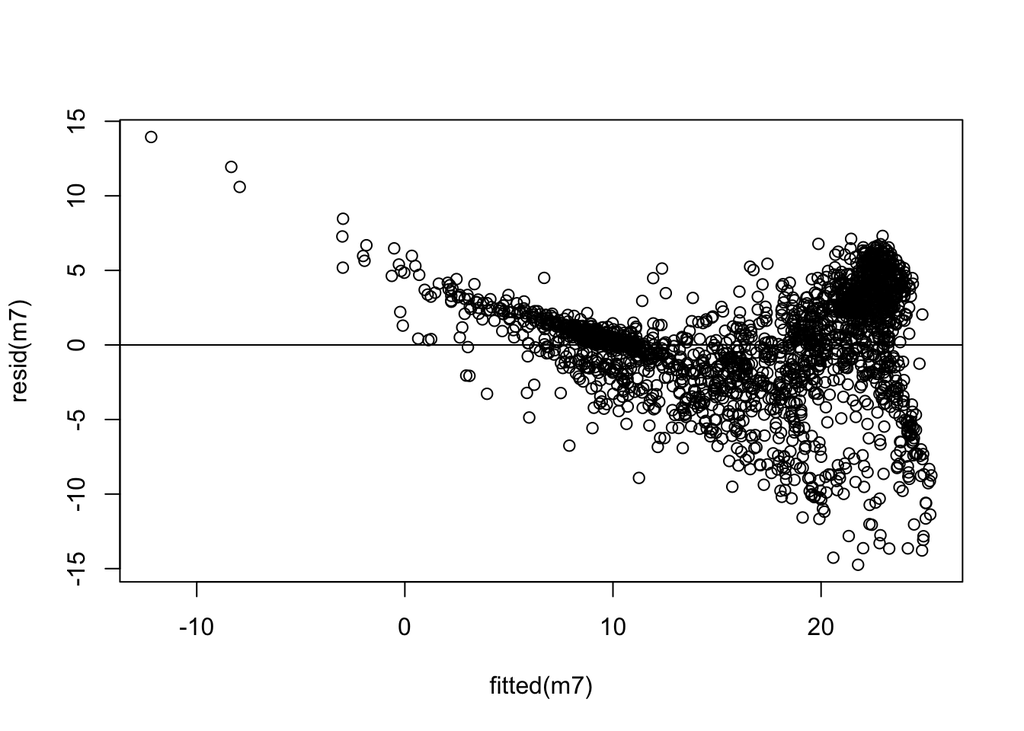

```
## integer(0)
```

```r
plot(fitted(m7), resid(m7)) +
  abline(h=0)
```

```r
msummary(m7, stars = TRUE, vcov = "robust")
```

|  | Model 1 |
| --- | --- |
| (Intercept) | 2.362*** |
|  | (0.197) |
| temp | 0.779*** |
|  | (0.012) |
| Num.Obs. | 1998 |
| R2 | 0.733 |
| R2 Adj. | 0.733 |
| AIC | 10998.5 |
| BIC | 11015.3 |
| Log.Lik. | −5496.246 |
| F | 4534.637 |
| Std.Errors | Robust |

+ p < 0.1, * p < 0.05, ** p < 0.01, *** p < 0.001

The standard errors differ from the classic to the robust models, so for that reason and the clear cone-shaped graph, I am confident that there is heteroskedasticity.

## Coding Question 8

```r
dengue <- dengue |> filter(!is.na(humid)) |>
  mutate(lnhumid = log(humid))
m8 <- lm(lnhumid ~ temp,
         data = dengue)
msummary(m8, stars = TRUE, vcov = "robust")
```

|  | Model 1 |
| --- | --- |
| (Intercept) | 1.659*** |
|  | (0.018) |
| temp | 0.056*** |
|  | (0.001) |
| Num.Obs. | 1998 |
| R2 | 0.770 |
| R2 Adj. | 0.770 |
| AIC | 116.1 |
| BIC | 132.9 |
| Log.Lik. | −55.027 |
| F | 4048.470 |
| Std.Errors | Robust |

+ p < 0.1, * p < 0.05, ** p < 0.01, *** p < 0.001

As the temperature increases one unit, the humidity increases by 5.7%.

## Coding Question 9

Shot in the dark: logging the dependent variable makes sense when an increase in X causes a percent change in Y instead of a straight unit change. One could imagine that the difference between 0 and 30 degrees Fahrenheit should matter less for humidity than the difference between 60 and 90 degrees Fahrenheit; in an unlogged model, they would count the same. Also, conveniently, there are no 0s in humidity, so the log transformation is easy.